# Introduction to SC19084

## Question **8.3**

The Count 5 test for equal variances in Section 6.4 is based on the maximum number of extreme points. Example 6.15 shows that the Count 5 criterion is not applicable for unequal sample sizes. Implement a permutation test for equal variance based on the maximum number of extreme points that applies when sample sizes are not necessarily equal.

## Answer for **8.3**

### Basic idea

Here is a test of equal variance.
$$H_{0}: \sigma_{1}^{2}=\sigma_{2}^{2} \text { vs } H_{a}: \sigma_{1}^{2} \neq \sigma_{2}^{2}$$
For testing the equality of variance of two sample, an observation is considered $extreme$ if it is not within the range of the other sample. We will implement a permutation test for equal variance based on the maximum number of extreme points that applies when sample sizes are not necessarily equal. At the same time, since Ball could be more powerful for non-location family distribution, it will be performed for comparison.

### Flowchart

1. Set two different sample sizes.
2. Set two different variances.
3. Write a function to obtain maximum number of extreme points which can be used in function $boot$.
4. Write a function to obtain p-value of permutation test.
5. Use Monte Carlo method to obtain p-values of the two test under two sorts of condition, saying $H_{0}$ is ture and $H_{0}$ is false, respectively.

### Code

```r
rm(list=ls())
# remove variables
library(boot);library(Ball)
# to obtain function
set.seed(234)
m<-1e3;R<-999
n1<-20;n2<-30
# different sample sizes
N<-c(n1,n2)
mu1<-mu2<-0
sigma1<-sigma2<-1
# equal variance
sigma3<-2
# unequal variance
Tn <- function(d,ix,sizes){
  n1<-sizes[1];n2<-sizes[2]
  n<-n1+n2
  ii<-ix[1:n1];jj<-ix[(n1+1):n]
  outx<-sum(d[ii]>max(d[jj]))+sum(d[ii]<min(d[jj]))
  outy<-sum(d[jj]>max(d[ii]))+sum(d[jj]<min(d[ii]))
  return(max(outx,outy))
}
# function to obtain maximum number of extreme points
myeq.test<-function(d){
  boot.obj<-boot(data=d,R=R,statistic=Tn,sim="permutation",sizes=N)
  ts<-c(boot.obj$t0,boot.obj$t)
  p.value<-mean(ts >= ts[1])
  return(p.value)
}
# function to obtain p.value of permutation test
p.values<-matrix(NA,m,4)
for(i in 1:m){
  x<-rnorm(n1,mu1,sigma1)
  y<-rnorm(n2,mu2,sigma2)
  z<-rnorm(n2,mu2,sigma3)
  d1<-c(x,y);d2<-c(x,z)
  p.values[i,1]<-bd.test(x=x,y=y,R=999,seed=i*123)$p.value
  # p.value of Ball test with H0 being TURE
  p.values[i,2]<-myeq.test(d1)
  # p.value of permutation test with H0 being TURE
  p.values[i,3]<-bd.test(x=x,y=z,R=999,seed=i*123)$p.value
  # p.value of Ball test with H0 being FALSE
  p.values[i,4]<-myeq.test(d2)
  # p.value of permutation test with H0 being FALSE
}
c<-matrix(colMeans(p.values),1,4)
colnames(c)<-c("bd.test(H0=T)","myeq.test(H0=T)","bd.test(H0=F)","myeq.test(H0=F)")
rownames(c)<-"p.value"
pander::pandoc.table(c)
```

|  | bd.test(H0=T) | myeq.test(H0=T) | bd.test(H0=F) | myeq.test(H0=F) |
| --- | --- | --- | --- | --- |
| **p.value** | 0.5118 | 0.5697 | 0.09126 | 0.04512 |

As is shown above, under the circumstances of equal variance, both Ball-test and permutation-test can not reject the null hypothesis, while permutaion-test being more likely to accept $H_{0}$. Nevertheless, when the null hypothesis was false, neither Ball nor permutation test would perform very well but the latter would show a smaller p-value.

### Wonder

Perform one permutation test to observe p-value more intuitively.

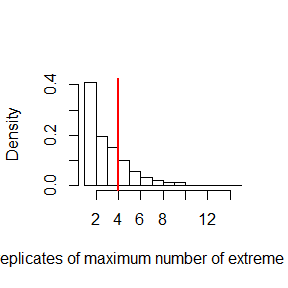

```r
set.seed(111)
ox<-rnorm(n1,mu1,sigma1)
oy<-rnorm(n2,mu2,sigma2)
od<-c(ox,oy)
obj.o<-boot(data=od,R=999,statistic=Tn,sim="permutation",sizes=N)
tb <- c(obj.o$t,obj.o$t0)
hist(tb, freq=FALSE, main="",xlab="replicates of maximum number of extreme points")
abline(v=obj.o$t0,col='red',lwd=2)
```

We can observe the original number of extreme points is 4<5, which is consistent with the result under Count 5 criterion.

## Question **sides**

Power comparison (distance correlation test versus ball covariance test)

Model 1:$Y=X / 4+e$

Model 2:$Y=X / 4 \times e$

$x \sim N\left(0_{2}, l_{2}\right), e \sim N\left(0_{2}, l_{2}\right), X$ and $e$ are independent

## Answer for **sides**

### Flowchart

1. Set number of p-value M for power.
2. Set sample size sequence.
3. For $\dot{l}^{t h}$ p-values With $j^{t h}$ sample size n, obtain $x$ $e$ from $\ N\left(0_{2}, l_{2}\right)$ independently.
4. Compute $y_{1}$ $y_{2}$ with two models.
5. Obtain $\dot{l}^{t h}$ p-values of two models using two sorts of test.
6. Obtain $j^{t h}$ power with $j^{t h}$ sample size.

### Code

I am so sorry for the awful answer. I have tried my best but my laptop can not run smoothly and I cannot figure what’s wrong with my second answer.So I put my procedure in the comment line. If you were so kind to debug my procedure, I would appreciate it very well. Apologize again.

```r
#rm(list=ls())
## remove variables
#library(Ball);library(MASS);library(boot)
#par(mfrow=c(1,2))
##set.seed(123)
#M<-100
##sample size for power
#alpha <- 0.1
#sigma<-matrix(c(1,0,0,1),2,2)
#dCov <- function(x, y){
#  x <- as.matrix(x)
#  y <- as.matrix(y)
#  n <- nrow(x)
#  m <- nrow(y)
#  if (n != m || n < 2) stop("Sample sizes must agree")
#  if (! (all(is.finite(c(x, y)))))
#  stop("Data contains missing or infinite values")
#  Akl <- function(x) {
#    d <- as.matrix(dist(x))
#    m <- rowMeans(d)
#    M <- mean(d)
#    a <- sweep(d, 1, m)
#    b <- sweep(a, 2, m)
#    return(b + M)
#  }
#  A<-Akl(x)
#  B<-Akl(y)
#  dCov<-sqrt(mean(A*B))
#  dCov
#}
#ndcov2 <- function(z, ix, dims) {
##dims contains dimensions of x and y
#p <- dims[1]
#q1 <- dims[2] + 1
#d <- p + dims[2]
#x <- z[ , 1:p] #leave x as is
#y <- z[ix, q1:d] #permute rows of y
#return(nrow(z) * (dCov(x,y))^2)
#}
#size<-seq(10,205,by=5)
## sample size sequence
#for(j in 1:40){
#  n<-size[j]
#  pow<-matrix(NA,40,4)
#  p.values<-matrix(NA,M,4)
#  for(i in 1:M){
#    set.seed(i*j*321)
#    x<-mvrnorm(n,rep(0,2),sigma)
#    e<-mvrnorm(n,rep(0,2),sigma)
#    y1<-x/4+e
#    y2<-x/4*e
#    p.values[i,1]<-bcov.test(x=x,y=y1,R=10,seed=i*121)$p.value
#    # p-value of Ball correlation test of model 1
#    m1<-matrix(cbind(x,y1),n,4)
#    boot.o1<-boot(data=m1,statistic=ndcov2,R=99,sim="permutation",dims=c(2,2))
#    t.b1<-c(boot.o1$t0,boot.o1$t)
#    p.values[i,2]<-mean(t.b1>=t.b1[1])
#    # p-value of distance correlation test of model 1
#    p.values[i,3]<-bcov.test(x=x,y=y2,R=99,seed=i*123)$p.value
#    # p-value of Ball correlation test of model 2
#    m2<-matrix(cbind(x,y2),n,4)
#    boot.o2<-boot(data=m2,statistic=ndcov2,R=99,sim="permutation",dims=c(2,2))
#    t.b2<-c(boot.o2$t0,boot.o2$t)
#    p.values[i,4]<-mean(t.b2>=t.b2[1])
#    # p-value of distance correlation test of model 2
#  }
#  pow[j,] <- colMeans(p.values<alpha)
#}
#plot(size,pow[,1], type = "l", xlab = "n", ylim = c(0,1),ylab="power",main="Model 1")
#  lines(size,pow[,2],lty=2)
#  legend("topleft",1,c("Ball","dCov"),lty=c(1,2),inset=.02)
#plot(size,pow[,3], type = "l", xlab = "n", ylim = c(0,1),ylab="power",main="Model 2")
#lines(size,pow[,4],lty=2)
#legend("topleft",1,c("Ball","dCov"),lty=c(1,2),inset=.02)
```

## Question **9.4**

Implement a random walk Metropolis sampler for generating the standard Laplace distribution (see Exercise 3.2). For the increment, simulate from a normal distribution. Compare the chains generated when different variances are used for the proposal distribution. Also, compute the acceptance rates of each chain.

## Answer for **9.4**

### Basic idea

Markov Chain Monte Carlo methods estimate the integral by Monte Carlo integration, and the Markov Chain provides the sampler that generates the random observations from the target distribution, saying the standard Laplace distribution here.

The standard Laplace distribution has density
$$f(x)=\frac{1}{2} e^{-|x|}, x \in \mathbb{R}$$

We choose a symmetric proposal distribution as $N\left(X_{t}, \sigma^{2}\right)$, in that the generated chain from it is able to converge to the standard Laplace distribution and enjoy irreducibility, positive recurrence, and aperiodicity.

### Flowchart

1. Generate $Y$ from $N\left(X_{t}, \sigma^{2}\right)$.
2. Given initial value $X_{0}$.
3. Generate $U$ from Uniform(0,1).
4. If
   $$U \leq \frac{f(Y)}{f\left(X_{t}\right)}$$

accept $Y$ and set $X_{t+1}=Y$ ; otherwise set $X_{t+1}=X_{t}$.

5. Increment $t$ until the chain has converged to a stationary distribution.
6. Repeating the simulation with different choices of $\sigma$

### Code

```r
rm(list=ls())
# remove variables
library(GeneralizedHyperbolic)
# to obtain function
set.seed(123)
N <- 2000
# iteration time
sigma <- c(.05, .5, 2, 16)
# different choices of sigma
x0<-25
# initial setting
myrw.Metropolis <- function(a, x0, N) {
  x <- numeric(N)
  x[1] <- x0
  u <- runif(N)
  k <- 0
  for (i in 2:N) {
    y <- rnorm(1, x[i-1], a)
    if (u[i] <= (dskewlap(y) / dskewlap(x[i-1])))
      x[i] <- y else {
        x[i] <- x[i-1]
        k <- k + 1
      }
  }
  return(list(x=x, k=k))
}
# function to generate the chain
r1 <- myrw.Metropolis(sigma[1], x0, N)
r2 <- myrw.Metropolis(sigma[2], x0, N)
r3 <- myrw.Metropolis(sigma[3], x0, N)
r4 <- myrw.Metropolis(sigma[4], x0, N)
c<-matrix(c(r1$k/N, r2$k/N, r3$k/N, r4$k/N),1,4)
colnames(c)<-c("sigma=0.05","sigma=0.5","sigma=2","sigma=16")
rownames(c)<-"rejection rate"
pander::pandoc.table(c)
```

|  | sigma=0.05 | sigma=0.5 | sigma=2 | sigma=16 |
| --- | --- | --- | --- | --- |
| **rejection rate** | 0.016 | 0.1685 | 0.472 | 0.905 |

As we can observe in the table, both the second and third chain have a rejection rate in the range [0.15, 0.5].

Then we will show what can happen to the random walk Metropolis sampler when the variance of proposal distribution change.

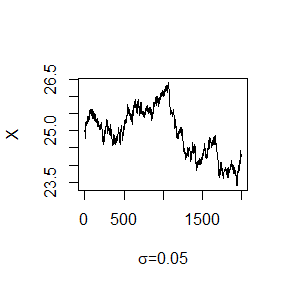

```r
#par(mfrow=c(2,2))
plot(r1$x,type='l',ylab="X",xlab=expression(paste(sigma,'=0.05')))
```

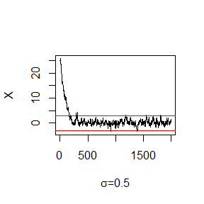

```r
# generated sample vs the time index when the variance of proposal distribution is 0.05
plot(r2$x,type='l',ylab="X",xlab=expression(paste(sigma,'=0.5')))
# generated sample vs the time index when the variance of proposal distribution is 0.5
 abline(h=-3,col='red',lwd=.3)
 abline(h=3,col='red',lwd=.3)
```

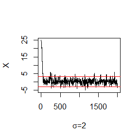

```r
 # convergence range
plot(r3$x,type='l',ylab="X",xlab=expression(paste(sigma,'=2')))
# generated sample vs the time index when the variance of proposal distribution is 4
abline(h=-3,col='red',lwd=.3)
abline(h=3,col='red',lwd=.3)
```

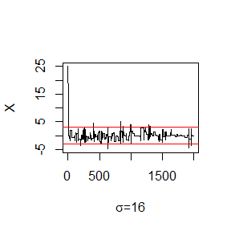

```r
# convergence range
plot(r4$x,type='l',ylab="X",xlab=expression(paste(sigma,'=16')))
# generated sample vs the time index when the variance of proposal distribution is 16
abline(h=-3,col='red',lwd=.3)
abline(h=3,col='red',lwd=.3)# convergence range
```

As is shown above, under the circumstances of proposal distribution with $N\left(X_{t}, 0.05^{2}\right)$, Chain 1 has not converged to the target in 2000 iterations. The chain in second($\sigma=0.5$) and third($\sigma=2$) plot converging to the target distribution while the former requires a little longer burn-in period. Finally, in the fourth plot, where $\sigma$= 16, most of the candidate points are rejected. The fourth chain converges, but it is inefficient.

### Wonder

We want to observe the relationship between generated sample and the target distribution in a more intuitive way. So the QQ plot and histogram of the generated sample with $N\left(X_{t}, 0.5^{2}\right)$ and $N\left(X_{t}, 2^{2}\right)$ density superimposed are shown below respectively.

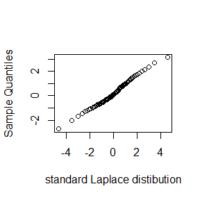

```r
#par(mfrow=c(2,2))
b <- 201 ; d<-101
#discard the burnin sample
y1 <- r2$x[b:N]
y2 <- r3$x[d:N]
a <- ppoints(100)
QR <- qskewlap(1-a)
# quantiles of Rayleigh
Q1 <- quantile(y1, a)
Q2 <- quantile(y2, a)
qqplot(QR, Q1, main="",xlab="standard Laplace distibution", ylab="Sample Quantiles")
```

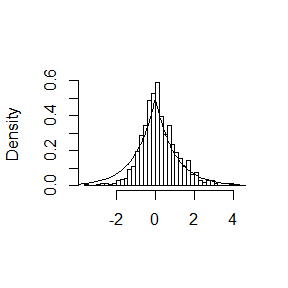

```r
hist(y1, breaks="scott", main="", xlab="", freq=FALSE)
lines(QR, dskewlap(QR))
```

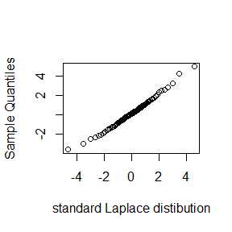

```r
qqplot(QR, Q2, main="",xlab="standard Laplace distibution", ylab="Sample Quantiles")
```

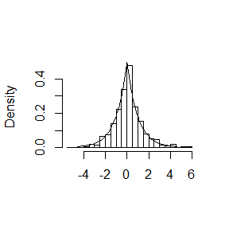

```r
hist(y2, breaks="scott", main="", xlab="", freq=FALSE)
lines(QR, dskewlap(QR))
```

## Question **11.1**

The natural logarithm and exponential functions are inverses of each other, so that mathematically $\log (\exp x)=\exp (\log x)=x$. Show by example that this property does not hold exactly in computer arithmetic. Does the identity hold with near equality? (See all.equal.)

## Answer for **11.1**

### Basic idea

It is well known that there are fundamental differences between mathematical calculations and computer calculations. Mathematical ideas such as limit, supremum, infimum, etc. cannot be exactly reproduced in the computer. Therefore, inverse transformation can not obtain the original result.

### Flowchart

1. Set the value of $x$.
2. Compute $\log \left(e^{x}\right)$.
3. Compute $e^{\log (x)}$.
4. Compare the two results with $x$.

### Code

```r
rm(list=ls())
# remove variables
x<-1e-50
y1<-log(exp(x))
y2<-exp(log(x))
c<-matrix(c(x,y1,y2),1,3)
colnames(c)<-c("x","log(exp(x))","exp(log(x))")
rownames(c)<-"value"
pander::pandoc.table(c)
```

|  | x | log(exp(x)) | exp(log(x)) |
| --- | --- | --- | --- |
| **value** | 1e-50 | 0 | 1e-50 |

We can observe $\log \left(\exp \left(10^{-50}\right)\right) \neq \exp \left(\log \left(10^{-50}\right)\right)=10^{-50}$

Now let us see how $all.equal$ will perform.

```r
isTRUE(all.equal(x,y1))
```

```
## [1] TRUE
```

Thus we know $\log \left(\exp \left(10^{-50}\right)\right)=\exp \left(\log \left(10^{-50}\right)\right)=10^{-50}$ hold with near equality.

### Wonder

How to avoid the bug of computer calculations?

In view of the comparision of $\log \left(\exp \left(10^{-50}\right)\right)$ and $\exp \left(\log \left(10^{-50}\right)\right)$, appropriate use of function$log$ might be an effective method to obtain correct computation.

## Question **11.5**

Write a function to solve the equation
$$\begin{aligned} \frac{2 \Gamma\left(\frac{k}{2}\right)}{\sqrt{\pi(k-1)} \Gamma\left(\frac{k-1}{2}\right)} \int_{0}^{c_{k-1}}\left(1+\frac{u^{2}}{k-1}\right)^{-k / 2} d u \\= \frac{2 \Gamma\left(\frac{k+1}{2}\right)}{\sqrt{\pi k} \Gamma\left(\frac{k}{2}\right)} \int_{0}^{c_{k}}\left(1+\frac{u^{2}}{k}\right)^{-(k+1) / 2} d u \end{aligned}$$
for a, where
$$c_{k}=\sqrt{\frac{a^{2} k}{k+1-a^{2}}}$$
Compare the solutions with the points $A(k)$ in Exercise 11.4.

## Answer for **11.5**

#### Basic idea

As we know, $X \sim t(n)$ when $X$ have the density function
$$f(x)=\frac{\Gamma\left(\frac{n+1}{2}\right)}{\sqrt{n \pi} \Gamma\left(\frac{n}{2}\right)}\left(1+\frac{x^{2}}{n}\right)^{-\frac{n+1}{2}}$$
Inspired by 11.4, we want to see the performance of two curves in section [0,sqrt(k)] for k=4 and 9.

Then find the possible section that exists root.

### Code

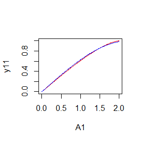

```r
rm(list=ls())
K<-c(4,9)
#par(mfrow=c(1,2))
A1<-seq(0,sqrt(K[1]),0.01)
A2<-seq(0,sqrt(K[2]),0.01)
g1<-function(x){(1+(x^2)/(k-1))^(-k/2)}
g2<-function(x){(1+(x^2)/k)^(-(k+1)/2)}
ck<-function(k,a){
  return(sqrt(a^2*k/(k+1-a^2)))
}
y11<-y12<-numeric(length(A1))
y21<-y22<-numeric(length(A2))
for(i in 1:length(A1)){
  a<-A1[i]
  k<-K[1]
y11[i]<-2*gamma(k/2)/(sqrt(pi*(k-1))*gamma((k-1)/2))*integrate(g1, lower=0, upper=ck(k-1,a))$value
y12[i]<-2*gamma((k+1)/2)/(sqrt(pi*k)*gamma(k/2))*integrate(g2,lower=0,upper=ck(k,a))$value
}
plot(A1,y11,type='l',col='red')
lines(A1,y12,col='blue')
```

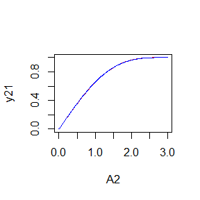

```r
for(i in 1:length(A2)){
  a<-A2[i]
  k<-K[2]
y21[i]<-2*gamma(k/2)/(sqrt(pi*(k-1))*gamma((k-1)/2))*integrate(g1, lower=0, upper=ck(k-1,a))$value
y22[i]<-2*gamma((k+1)/2)/(sqrt(pi*k)*gamma(k/2))*integrate(g2,lower=0,upper=ck(k,a))$value
}
plot(A2,y21,type='l',col='red')
lines(A2,y22,col='blue')
```

We choose sqrt(k)/2+1 as the upper of our area to extract root.

```r
rm(list=ls())
# remove variables
K<-c(4:25,100)
# different k
N<-length(K)
f1 <- function(x) {
  2*gamma(k/2)/(sqrt(pi*(k-1))*gamma((k-1)/2))*(1+(x^2)/(k-1))^(-k/2)
}
# integrand 1
f2<-function(x) {
  2*gamma((k+1)/2)/(sqrt(pi*k)*gamma(k/2))*(1+(x^2)/k)^(-(k+1)/2)
}
# integrand 2
ck<-function(k,a){
  return(sqrt(a^2*k/(k+1-a^2)))
}
# integral upper limit
A<-numeric(N)
for(i in 1:N){
  k<-K[i]
  ss<-uniroot(function(a){
  integrate(f1, lower=0, upper=ck(k-1,a))$value-integrate(f2,lower=0,upper=ck(k,a))$value
    },lower=0.5,upper=sqrt(k)/2+1)
  A[i]<-ss$root
}
```

So, roots of the equation for k=4:25;100 are stored in vector A.

## Question **3**

A-B-O blood type problem

Let the three alleles be A, B, and O with allele frequencies p,q, and r. The 6 genotype frequencies under HWE and complete counts are as follows.
$$\begin{array}{|c|c|c|c|c|c|}\hline \text { Genotype } & {A A} & {B B} & {O O} & {A O} & {B O} & {A B} & {S u m} \\ \hline \text { Frequency } & {p^{\sim} 2} & {q^{\sim 2}} & {r^{\sim 2}} & {2 p r} & {2 q r} & {2 p q} & {1} \\ \hline \text { Count } & {n A A} & {n B B} & {n O O} & {n A O} & {n B O} & {n A B} & {n} \\ \hline\end{array}$$
Observed data: $n_{A}=n_{A A}+n_{A O}=28$(A-type),$n_{B .}=n_{B B}+n_{B O}=24$(B-type), $n_{O O}=41$ (O-type),$n_{A B}=70$ (AB-type).

1. Use EM algorithm to solve MLE of p and q (consider missing data $n_{A A}$ and $n_{B B}$ ).
2. Show that the log-maximum likelihood values in M-steps are increasing via line plot.

## Answer for **3**

### Basic idea

Observed data likelyhood:

$$\begin{array}{l}{L\left(p, q | n_{A}, n_{B}, n_{O O}, n_{A B}\right)=\left(p^{2}+2 p r\right)^{n_{A}}\left(q^{2}+2 q r\right)^{n_{B} .}\left(r^{2}\right)^{n_{O O}}(2 p q)^{n_{4 B}}} \end{array}$$

Complete data likelyhood:

$$\begin{array}{l}{L\left(p, q | n_{A A}, n_{B B}, n_{O O}, n_{A O}, n_{B O}\right)=\left(p^{2}\right)^{n_{4 A}}\left(q^{2}\right)^{n_{B 8}}\left(r^{2}\right)^{n_{O O}}(2 p r)^{n_{B O}}(2 q r)^{n_{S O}}(2 p q)^{n_{A B}}}\end{array}$$

After logarithm:

$$\begin{aligned} \ln L=& 2 n_{A A} \log (p)+2 n_{B B} \log (q)+2 n_{O O} \log (r)+\left(n_{\cdot A}-n_{A A}\right) \log (2 p r) \\ &+\left(n_{B .}-n_{B B}\right) \log (2 q r)+n_{A B} \log (2 p q) \ \end{aligned}$$

$E$xpectation step:

$$\begin{aligned} \ E_{\hat{p}_{0}, \hat{q}_{0}}(\ln L)=& \frac{2 \hat{p}_{0}}{\hat{p}_{0}^{2}+2 \hat{p}_{0} \hat{r}_{0}} n_{A} \log (p)+\frac{2 \hat{q}_{0}}{\hat{q}_{0}^{2}+2 \hat{q}_{0} \hat{r}_{0}} n_{B} \log (q)+2 n_{O O} \log (r) \\ &+n_{A} \cdot \frac{2 \hat{p}_{0} \hat{r}_{0}}{\hat{p}_{0}^{2}+2 \hat{p}_{0} \hat{r}_{0}} \log (2 p r)+n_{B} \cdot \frac{2 \hat{q}_{0} \hat{r}_{0}}{\hat{q}_{0}^{2}+2 \hat{q}_{0} \hat{r}_{0}} \log (2 q r)+n_{A B} \log (2 p q) \end{aligned}$$

$\hat{r}_{0}=1-\hat{p}_{0}-\hat{q}_{0}$ $r=1-p-q$

Thus we can obtain $\hat{p}_{1}$ and $\hat{q}_{1}$ though MLE

Update the estimates and iteratively repeat the $E$ step and $M$ steps until the algorithm converges to some criterion.

### Code

```r
rm(list=ls())
# remove variables
library(rootSolve)
N <- 2e2
# max. number of the iteration
nA<-28;nB<-24;nOO<-41;nAB<-70
G <- c(.5,.4)
# initial estimates
tol <- .Machine$double.eps^0.5
G.old <- G+1
E <- numeric(N)
for(j in 1:N){
  E[j]<-2*G[1]*nA*log(G[1])/(2-G[1]-2*G[2])+2*G[2]*nB*log(G[2])/(2-G[2]-2*G[1])+2*nOO*log(1-G[1]-G[2])+nA*(2-2*G[1]-2*G[2])*log(2*G[1]*(1-G[1]-G[2]))/(2-G[1]-2*G[2])+nB*(2-2*G[1]-2*G[2])*log(2*G[2]*(1-G[1]-G[2]))/(2-G[2]-2*G[1])+nAB*log(2*G[1]*G[2])
  model<-function(x){
    F1<-2*G[1]*nA/((2-G[1]-2*G[2])*x[1])-2*nOO/(1-x[1]-x[2])+nA*(2-2*G[1]-2*G[2])*(1-2*x[1]-x[2])/((2-G[1]-2*G[2])*x[1]*(1-x[1]-x[2]))-nB*(2-2*G[1]-2*G[2])/((2-G[2]-2*G[1])*(1-x[1]-x[2]))+nAB/x[1]
    F2<-2*G[2]*nB/((2-G[2]-2*G[1])*x[2])-2*nOO/(1-x[1]-x[2])-nA*(2-2*G[1]-2*G[2])/((2-G[1]-2*G[2])*(1-x[1]-x[2]))+nB*(2-2*G[1]-2*G[2])*(1-2*x[2]-x[1])/((2-G[2]-2*G[1])*x[2]*(1-x[1]-x[2]))+nAB/x[2]
    c(F1=F1,F2=F2)
  }
  ss<-multiroot(f=model,star=c(.1,.1))
  G<-ss$root
  # update p and q
  if (sum(abs(G-G.old)/G.old)<tol) break
  G.old<-G
}
print(G.old)
```

[1] 0.3273442 0.3104267

Therefore we obtained MLE of p and q, say 0.327 and 0.31 respectively.

Now let us show the log-maximum likelihood values in M-steps via line plot.

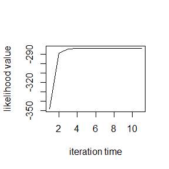

```r
plot(E[1:11],type='l',xlab="iteration time",ylab="likelihood value")
```

As shown above, we can observe that the log-maximum likelihood values are increasing in M-steps.

## Question **11.1.2 Exercise 3**

Use both for loops and lapply() to fit linear models to the mtcars using the formulas stored in this list:

formulas <- list(

mpg ~ disp,

mpg ~ I(1 / disp),

mpg ~ disp + wt,

mpg ~ I(1 / disp) + wt

)

## Answer for **11.1.2 Exercise 3**

### Processes and Code

First, we use $for$ loops to fit linear models as we learned before and store the results in $fit1$.

```r
rm(list=ls())
# remove variables
attach(mtcars)
formulas <- list(
mpg ~ disp,
mpg ~ I(1 / disp),
mpg ~ disp + wt,
mpg ~ I(1 / disp) + wt
)
fit11<-vector("list",length(formulas))
cof11<-matrix(0,4,3)
for(i in seq_along(formulas)){
  fit11[[i]]<-lm(formulas[[i]])
  cof11[i,1:length(fit11[[i]]$coefficients)]<-fit11[[i]]$coefficients
}
colnames(cof11)<-c("intercept","coefficient1","coefficient2")
rownames(cof11)<-c("mpg ~ disp","mpg ~ I(1 / disp)","mpg ~ disp + wt","mpg ~ I(1 / disp) + wt")
pander::pandoc.table(cof11)
```

|  | intercept | coefficient1 | coefficient2 |
| --- | --- | --- | --- |
| **mpg ~ disp** | 29.6 | -0.04122 | 0 |
| **mpg ~ I(1 / disp)** | 10.75 | 1558 | 0 |
| **mpg ~ disp + wt** | 34.96 | -0.01772 | -3.351 |
| **mpg ~ I(1 / disp) + wt** | 19.02 | 1143 | -1.798 |

Now we use $lapply$ to realize it.

```r
fit12<-lapply(formulas,lm)
cof12<-matrix(0,4,3)
for(i in seq_along(formulas)){
  cof12[i,1:length(fit12[[i]]$coefficients)]<-fit12[[i]]$coefficients
}
colnames(cof12)<-c("intercept","coefficient1","coefficient2")
rownames(cof12)<-c("mpg ~ disp","mpg ~ I(1 / disp)","mpg ~ disp + wt","mpg ~ I(1 / disp) + wt")
pander::pandoc.table(cof12)
```

|  | intercept | coefficient1 | coefficient2 |
| --- | --- | --- | --- |
| **mpg ~ disp** | 29.6 | -0.04122 | 0 |
| **mpg ~ I(1 / disp)** | 10.75 | 1558 | 0 |
| **mpg ~ disp + wt** | 34.96 | -0.01772 | -3.351 |
| **mpg ~ I(1 / disp) + wt** | 19.02 | 1143 | -1.798 |

## Question **11.1.2 Exercise 4**

Fit the model mpg ~ disp to each of the bootstrap replicates of mtcars in the list below by using a for loop and lapply(). Can you do it without an anonymous function?

bootstraps <- lapply(1:10, function(i) {

rows <- sample(1:nrow(mtcars), rep = TRUE)

mtcars[rows, ]

})

## Answer for **11.1.2 Exercise 4**

### Processes and Code

First, we use $for$ loops to fit the model mpg ~ disp to each of the bootstrap replicates and show the coefficients.

```r
bootstraps <- lapply(1:10, function(i) {
rows <- sample(1:nrow(mtcars), rep = TRUE)
mtcars[rows, ]
})
fit21<-vector("list",length(bootstraps))
cof21<-matrix(0,10,2)
for(i in seq_along(bootstraps)){
  fit21[[i]]<-lm(bootstraps[[i]]$mpg~bootstraps[[i]]$disp)
  cof21[i,]<-fit21[[i]]$coefficients
}
colnames(cof21)<-c("intercept","coefficient")
rownames(cof21)<-c("rep1","rep2","rep3","rep4","rep5","rep6","rep7","rep8","rep9","rep10")
pander::pandoc.table(cof21)
```

|  | intercept | coefficient |
| --- | --- | --- |
| **rep1** | 26.72 | -0.03241 |
| **rep2** | 29.79 | -0.04157 |
| **rep3** | 29.39 | -0.03905 |
| **rep4** | 27.81 | -0.03279 |
| **rep5** | 31.14 | -0.04697 |
| **rep6** | 30.05 | -0.04754 |
| **rep7** | 31.19 | -0.04648 |
| **rep8** | 28.23 | -0.03622 |
| **rep9** | 26.74 | -0.03122 |
| **rep10** | 30.37 | -0.04073 |

Then we use $lapply$ to fit the models.

```r
fit22<-lapply(bootstraps,function(x){
  lm(x$mpg~x$disp)
})
cof22<-matrix(0,10,2)
for(i in seq_along(bootstraps)){
  cof22[i,]<-fit22[[i]]$coefficients
}
colnames(cof22)<-c("intercept","coefficient")
rownames(cof22)<-c("rep1","rep2","rep3","rep4","rep5","rep6","rep7","rep8","rep9","rep10")
pander::pandoc.table(cof22)
```

|  | intercept | coefficient |
| --- | --- | --- |
| **rep1** | 26.72 | -0.03241 |
| **rep2** | 29.79 | -0.04157 |
| **rep3** | 29.39 | -0.03905 |
| **rep4** | 27.81 | -0.03279 |
| **rep5** | 31.14 | -0.04697 |
| **rep6** | 30.05 | -0.04754 |
| **rep7** | 31.19 | -0.04648 |
| **rep8** | 28.23 | -0.03622 |
| **rep9** | 26.74 | -0.03122 |
| **rep10** | 30.37 | -0.04073 |

Finally, we try to do it without an anonymous function.

```r
fit23<-lapply(bootstraps,lm,formula=mpg~disp)
cof23<-matrix(0,10,2)
for(i in seq_along(bootstraps)){
  cof23[i,]<-fit23[[i]]$coefficients
}
colnames(cof23)<-c("intercept","coefficient")
rownames(cof23)<-c("rep1","rep2","rep3","rep4","rep5","rep6","rep7","rep8","rep9","rep10")
pander::pandoc.table(cof23)
```

|  | intercept | coefficient |
| --- | --- | --- |
| **rep1** | 26.72 | -0.03241 |
| **rep2** | 29.79 | -0.04157 |
| **rep3** | 29.39 | -0.03905 |
| **rep4** | 27.81 | -0.03279 |
| **rep5** | 31.14 | -0.04697 |
| **rep6** | 30.05 | -0.04754 |
| **rep7** | 31.19 | -0.04648 |
| **rep8** | 28.23 | -0.03622 |
| **rep9** | 26.74 | -0.03122 |
| **rep10** | 30.37 | -0.04073 |

## Question **11.1.2 Exercise 5**

For each model in the previous two exercises, extract R2 using the function below.

rsq <- function(mod) summary(mod)$r.squared

## Answer for **11.1.2 Exercise 5**

### Processes and Code

For Exercise 3, we extract R2 for $lapply$ model.

```r
rsq <- function(mod) summary(mod)$r.square
rsq1 <- lapply(fit12,rsq)
r_squared1<-matrix(rsq1,4,1)
colnames(r_squared1)<-"R_squared"
rownames(r_squared1)<-c("mpg ~ disp","mpg ~ I(1 / disp)","mpg ~ disp + wt","mpg ~ I(1 / disp) + wt")
pander::pandoc.table(r_squared1)
```

|  | R_squared |
| --- | --- |
| **mpg ~ disp** | 0.7183433 |
| **mpg ~ I(1 / disp)** | 0.8596865 |
| **mpg ~ disp + wt** | 0.7809306 |
| **mpg ~ I(1 / disp) + wt** | 0.8838038 |

For Exercise 4, we extract R2 for $lapply$ model without an anonymous function.

```r
rsq2 <- lapply(fit23,rsq)
r_squared2<-matrix(rsq2,10,1)
colnames(r_squared2)<-"R_squared"
rownames(r_squared2)<-c("rep1","rep2","rep3","rep4","rep5","rep6","rep7","rep8","rep9","rep10")
pander::pandoc.table(r_squared2)
```

|  | R_squared |
| --- | --- |
| **rep1** | 0.8034013 |
| **rep2** | 0.7386716 |
| **rep3** | 0.6572146 |
| **rep4** | 0.6786082 |
| **rep5** | 0.7559773 |
| **rep6** | 0.7712581 |
| **rep7** | 0.6752694 |
| **rep8** | 0.6337313 |
| **rep9** | 0.6508021 |
| **rep10** | 0.7325716 |

## Question **11.2.5 Exercise 3**

The following code simulates the performance of a t-test for non-normal data. Use sapply() and an anonymous function to extract the p-value from every trial.

trials <- replicate(

100,

t.test(rpois(10, 10), rpois(7, 10)),

simplify = FALSE

)

Extra challenge: get rid of the anonymous function by using [[ directly.

## Answer for **11.2.5 Exercise 3**

We extract the p-value from every trial and take the first 5 for example.

```r
rm(list=ls())
# remove variables
trials <- replicate(
100,
t.test(rpois(10, 10), rpois(7, 10)),
simplify = FALSE
)
p_value<-sapply(trials,function(x) return(x$p.value))
p<-matrix(p_value[1:5],5,1)
colnames(p)<-"p_value"
rownames(p)<-c("trial1","trial2","trial3","trial4","trial5")
pander::pandoc.table(p)
```

|  | p_value |
| --- | --- |
| **trial1** | 0.7732 |
| **trial2** | 0.424 |
| **trial3** | 0.1576 |
| **trial4** | 0.7405 |
| **trial5** | 0.5048 |

Also, we shall use $sapply()$ without an anonymous function.

```r
p_value2<-sapply(trials,'[[',3)
p2<-matrix(p_value2[1:5],5,1)
colnames(p2)<-"p_value"
rownames(p2)<-c("trial1","trial2","trial3","trial4","trial5")
pander::pandoc.table(p2)
```

|  | p_value |
| --- | --- |
| **trial1** | 0.7732 |
| **trial2** | 0.424 |
| **trial3** | 0.1576 |
| **trial4** | 0.7405 |
| **trial5** | 0.5048 |

## Question **11.2.5 Exercise 7**

Implement mcsapply() , a multicore version of sapply() . Can you implement mcvapply() , a parallel version of vapply() ? Why or why not?

## Answer for **11.2.5 Exercise 7**

First, we implement a multicore version of sapply(), named as mcsapply().

```r
rm(list=ls())
# remove variables
library(parallel)
attach(mtcars)
cores <- detectCores()
cluster <- makePSOCKcluster(cores)
#  set up a local cluster
mcsapply <- function(x, f, ...) {
res <- parLapply(cluster, x, f)
simplify2array(res)
}
```

```r
boot_df <- function(x) x[sample(nrow(x), rep = T), ]
boot_lm <- function(i) {
  return(summary(lm(mpg ~ wt + disp, data = mtcars[sample(nrow(mtcars), rep = T), ]))$r.square)
}
T1<-system.time(sapply(1:500, boot_lm))
T2<-system.time(mcsapply(1:500, boot_lm))
c<-matrix(c(T1[1:3],T2[1:3]),2,3)
colnames(c)<-c("user","system","elapsed")
rownames(c)<-c("sapply","mcsapply")
pander::pandoc.table(c)
```

|  | user | system | elapsed |
| --- | --- | --- | --- |
| **sapply** | 1.01 | 1.07 | 0.01 |
| **mcsapply** | 0 | 0 | 0.31 |

Then come the parallel version of vapply(). We do not think it is implementable in view of $vapply()$ shall check the length and type of results in appling function to each element in a list.

## Question **AR2**

Implement a random walk Metropolis sampler for generating the standard Laplace distribution (see Exercise 3.2). For the increment, simulate from a normal distribution. Compare the chains generated when different variances are used for the proposal distribution. Also, compute the acceptance rates of each chain.

## Answer for **AR2**

### Basic idea

Markov Chain Monte Carlo methods estimate the integral by Monte Carlo integration, and the Markov Chain provides the sampler that generates the random observations from the target distribution, saying the standard Laplace distribution here.

The standard Laplace distribution has density
$$f(x)=\frac{1}{2} e^{-|x|}, x \in \mathbb{R}$$

We choose a symmetric proposal distribution as $N\left(X_{t}, \sigma^{2}\right)$, in that the generated chain from it is able to converge to the standard Laplace distribution and enjoy irreducibility, positive recurrence, and aperiodicity.

### Flowchart

1. Generate $Y$ from $N\left(X_{t}, \sigma^{2}\right)$.
2. Given initial value $X_{0}$.
3. Generate $U$ from Uniform(0,1).
4. If
   $$U \leq \frac{f(Y)}{f\left(X_{t}\right)}$$

accept $Y$ and set $X_{t+1}=Y$ ; otherwise set $X_{t+1}=X_{t}$.

5. Increment $t$ until the chain has converged to a stationary distribution.
6. Repeating the simulation with different choices of $\sigma$

### Code

```r
rm(list=ls())
# remove variables
library(GeneralizedHyperbolic)
# to obtain function
library(Rcpp)
# Attach R package "Rcpp"
#dir_cpp<-'Rcpp/'
# Can create source file in Rstudio
#sourceCpp(paste0(dir_cpp,"MetropolisC.cpp"))
library(microbenchmark)
set.seed(123)
N <- 2000
# iteration time
sigma <- c(.05, .5, 2, 16)
# different choices of sigma
x0<-25
# initial setting
myrw.Metropolis <- function(a, x0, N) {
  x <- numeric(N)
  x[1] <- x0
  u <- runif(N)
  k <- 0
  for (i in 2:N) {
    y <- rnorm(1, x[i-1], a)
    if (u[i] <= (dskewlap(y) / dskewlap(x[i-1])))
      x[i] <- y else {
        x[i] <- x[i-1]
        k <- k + 1
      }
  }
  return(list(x=x, k=k))
}
# function to generate the chain
r1 <- myrw.Metropolis(sigma[1], x0, N)
r2 <- myrw.Metropolis(sigma[2], x0, N)
r3 <- myrw.Metropolis(sigma[3], x0, N)
r4 <- myrw.Metropolis(sigma[4], x0, N)
# results by R
#r11 <-MetropolisC(sigma[1], x0, N)
#r21 <- MetropolisC(sigma[2], x0, N)
#r31 <- MetropolisC(sigma[3], x0, N)
#r41 <- MetropolisC(sigma[4], x0, N)
# results by Rcpp
c<-matrix(c(r1$k/N, r2$k/N, r3$k/N, r4$k/N),1,4)
colnames(c)<-c("sigma=0.05","sigma=0.5","sigma=2","sigma=16")
rownames(c)<-"rejection rate(R)"
pander::pandoc.table(c)
```

|  | sigma=0.05 | sigma=0.5 | sigma=2 | sigma=16 |
| --- | --- | --- | --- | --- |
| **rejection rate(R)** | 0.016 | 0.1685 | 0.472 | 0.905 |

```r
#b<-matrix(c(r11[N+1]/N, r21[N+1]/N, r31[N+1]/N, r41[N+1]/N),1,4)
#colnames(b)<-c("sigma=0.05","sigma=0.5","sigma=2","sigma=16")
#rownames(b)<-"rejection rate(Rcpp)"
#pander::pandoc.table(b)
```

As we can observe in the table, both the second and third chain have a rejection rate in the range [0.15, 0.5].

```r
#par(mfrow=c(2,2))
#plot(r11[1:N],type='l',ylab="X",xlab=expression(paste(sigma,'=0.05')))
# generated sample vs the time index when the variance of proposal distribution is 0.05
#plot(r21[1:N],type='l',ylab="X",xlab=expression(paste(sigma,'=0.5')))
# generated sample vs the time index when the variance of proposal distribution is 0.5
 #abline(h=-3,col='red',lwd=.3)
 #abline(h=3,col='red',lwd=.3)
 # convergence range
#plot(r31[1:N],type='l',ylab="X",xlab=expression(paste(sigma,'=2')))
# generated sample vs the time index when the variance of proposal distribution is 4
#abline(h=-3,col='red',lwd=.3)
#abline(h=3,col='red',lwd=.3)
# convergence range
#plot(r41[1:N],type='l',ylab="X",xlab=expression(paste(sigma,'=16')))
# generated sample vs the time index when the variance of proposal distribution is 16
#abline(h=-3,col='red',lwd=.3)
#abline(h=3,col='red',lwd=.3)# convergence range
```

```r
#par(mfrow=c(2,2))
b <- 201 ; d<-101
#discard the burnin sample
y1 <- r2$x[b:N]
#y11<-r21[b:N]
y2 <- r3$x[d:N]
#y21<-r31[b:N]
a <- ppoints(100)
#QR <- qskewlap(1-a)
# quantiles of Rayleigh
Q1 <- quantile(y1, a)
#Q11<-quantile(y11, a)
Q2 <- quantile(y2, a)
#Q21<-quantile(y21, a)
#qqplot(Q1, Q11, main="",xlab="R Sample Quantiles", ylab="Rcpp Sample Quantiles")
#hist(y11, breaks="scott", main="", xlab="", freq=FALSE)
#lines(QR, dskewlap(QR))
#qqplot(Q2, Q21, main="",xlab="R Sample Quantiles", ylab="Rcpp Sample Quantiles")
#hist(y21, breaks="scott", main="", xlab="", freq=FALSE)
#lines(QR, dskewlap(QR))
```

```r
#ts <- microbenchmark(MetropolisR=myrw.Metropolis(sigma[1], x0, N),
#                     MetropolisCpp=MetropolisC(sigma[1], x0, N))
#summary(ts)[,c(1,3,5,6)]
```